# Quantium Virtual Internship - Retail Strategy and Analytics - Task 1

## Load required libraries and datasets

#### Point the filePath to where you have downloaded the datasets to and

#### assign the data files to data.tables

```r
filePath <- "/Volumes/Seagate_Haykay/Quantium_Data_Analytics"
setwd(filePath)
```

```
The working directory was changed to /Volumes/Seagate_Haykay/Quantium_Data_Analytics inside a notebook chunk. The working directory will be reset when the chunk is finished running. Use the knitr root.dir option in the setup chunk to change the working directory for notebook chunks.
```

```r
getwd()
```

```
[1] "/Volumes/Seagate_Haykay/Quantium Analytics"
```

```r
filePath <- "/Volumes/Seagate_Haykay/Quantium_Data_Analytics"
transactionData <- fread(paste0(filePath,"/QVI_transaction_data.csv"))
customerData <- fread(paste0(filePath,"/QVI_purchase_behaviour.csv"))
```

## Exploratory data analysis

```r
#### Examine transaction data
head(transactionData)
```

| DATE | STORE_NBR | LYLTY_CARD_NBR | TXN_ID | PROD_NBR | PROD_NAME | PROD_QTY | TOT_SALES |
| --- | --- | --- | --- | --- | --- | --- | --- |
| 2018-10-17 | 1 | 1000 | 1 | 5 | Natural Chip Compny SeaSalt175g | 2 | 6.0 |
| 2019-05-14 | 1 | 1307 | 348 | 66 | CCs Nacho Cheese 175g | 3 | 6.3 |
| 2019-05-20 | 1 | 1343 | 383 | 61 | Smiths Crinkle Cut Chips Chicken 170g | 2 | 2.9 |
| 2018-08-17 | 2 | 2373 | 974 | 69 | Smiths Chip Thinly S/Cream&Onion 175g | 5 | 15.0 |
| 2018-08-18 | 2 | 2426 | 1038 | 108 | Kettle Tortilla ChpsHny&Jlpno Chili 150g | 3 | 13.8 |
| 2019-05-19 | 4 | 4074 | 2982 | 57 | Old El Paso Salsa Dip Tomato Mild 300g | 1 | 5.1 |

```r
#### Examine customer data
head(customerData)
```

| LYLTY_CARD_NBR | LIFESTAGE | PREMIUM_CUSTOMER |
| --- | --- | --- |
| 1000 | YOUNG SINGLES/COUPLES | Premium |
| 1002 | YOUNG SINGLES/COUPLES | Mainstream |
| 1003 | YOUNG FAMILIES | Budget |
| 1004 | OLDER SINGLES/COUPLES | Mainstream |
| 1005 | MIDAGE SINGLES/COUPLES | Mainstream |
| 1007 | YOUNG SINGLES/COUPLES | Budget |

Let’s check if columns we would expect to be numeric are in numeric form and date columns are in date format.

```r
#### Convert DATE column to a date format
#### A quick search online tells us that CSV and Excel integer dates begin on 30 Dec 1899
transactionData$DATE <- as.Date(transactionData$DATE, origin = "1899-12-30")
head(transactionData)
```

| DATE | STORE_NBR | LYLTY_CARD_NBR | TXN_ID | PROD_NBR | PROD_NAME | PROD_QTY | TOT_SALES |
| --- | --- | --- | --- | --- | --- | --- | --- |
| 2018-10-17 | 1 | 1000 | 1 | 5 | Natural Chip Compny SeaSalt175g | 2 | 6.0 |
| 2019-05-14 | 1 | 1307 | 348 | 66 | CCs Nacho Cheese 175g | 3 | 6.3 |
| 2019-05-20 | 1 | 1343 | 383 | 61 | Smiths Crinkle Cut Chips Chicken 170g | 2 | 2.9 |
| 2018-08-17 | 2 | 2373 | 974 | 69 | Smiths Chip Thinly S/Cream&Onion 175g | 5 | 15.0 |
| 2018-08-18 | 2 | 2426 | 1038 | 108 | Kettle Tortilla ChpsHny&Jlpno Chili 150g | 3 | 13.8 |
| 2019-05-19 | 4 | 4074 | 2982 | 57 | Old El Paso Salsa Dip Tomato Mild 300g | 1 | 5.1 |

We should check that we are looking at the right products by examining PROD_NAME.

```r
#### Examine PROD_NAME
summary(transactionData$PROD_NAME)
```

```
   Length     Class      Mode
   264836 character character
```

```r
PROD_NAME <- (transactionData$PROD_NAME)
head(PROD_NAME)
```

```
[1] "Natural Chip        Compny SeaSalt175g"
[2] "CCs Nacho Cheese    175g"
[3] "Smiths Crinkle Cut  Chips Chicken 170g"
[4] "Smiths Chip Thinly  S/Cream&Onion 175g"
[5] "Kettle Tortilla ChpsHny&Jlpno Chili 150g"
[6] "Old El Paso Salsa   Dip Tomato Mild 300g"
```

Looks like we are definitely looking at potato chips but how can we check that these are all chips? We can do some basic text analysis by summarising the individual words in the product name.

```r
#### Examine the words in PROD_NAME to see if there are any incorrect entries
#### such as products that are not chips
productWords <- data.table(unlist(strsplit(unique(transactionData[, transactionData$PROD_NAME]), "
")))
setnames(productWords, 'words')
head(transactionData)
```

| DATE | STORE_NBR | LYLTY_CARD_NBR | TXN_ID | PROD_NBR | PROD_NAME | PROD_QTY | TOT_SALES |
| --- | --- | --- | --- | --- | --- | --- | --- |
| 2018-10-17 | 1 | 1000 | 1 | 5 | Natural Chip Compny SeaSalt175g | 2 | 6.0 |
| 2019-05-14 | 1 | 1307 | 348 | 66 | CCs Nacho Cheese 175g | 3 | 6.3 |
| 2019-05-20 | 1 | 1343 | 383 | 61 | Smiths Crinkle Cut Chips Chicken 170g | 2 | 2.9 |
| 2018-08-17 | 2 | 2373 | 974 | 69 | Smiths Chip Thinly S/Cream&Onion 175g | 5 | 15.0 |
| 2018-08-18 | 2 | 2426 | 1038 | 108 | Kettle Tortilla ChpsHny&Jlpno Chili 150g | 3 | 13.8 |
| 2019-05-19 | 4 | 4074 | 2982 | 57 | Old El Paso Salsa Dip Tomato Mild 300g | 1 | 5.1 |

As we are only interested in words that will tell us if the product is chips or not, let’s remove all words with digits and special characters such as ‘&’ from our set of product words. We can do this using `grepl()`.

```r
# Remove digits, and special characters, and then sort the distinct words by frequency of occurrence.

#### Removing digits
transactionData$PROD_NAME <- data.table(gsub("\\w*[0-9]+\\w*", "", transactionData$PROD_NAME))

head(transactionData)
```

| DATE | STORE_NBR | LYLTY_CARD_NBR | TXN_ID | PROD_NBR | PROD_NAME | PROD_QTY | TOT_SALES |
| --- | --- | --- | --- | --- | --- | --- | --- |
| 2018-10-17 | 1 | 1000 | 1 | 5 | Natural Chip Compny | 2 | 6.0 |
| 2019-05-14 | 1 | 1307 | 348 | 66 | CCs Nacho Cheese | 3 | 6.3 |
| 2019-05-20 | 1 | 1343 | 383 | 61 | Smiths Crinkle Cut Chips Chicken | 2 | 2.9 |
| 2018-08-17 | 2 | 2373 | 974 | 69 | Smiths Chip Thinly S/Cream&Onion | 5 | 15.0 |
| 2018-08-18 | 2 | 2426 | 1038 | 108 | Kettle Tortilla ChpsHny&Jlpno Chili | 3 | 13.8 |
| 2019-05-19 | 4 | 4074 | 2982 | 57 | Old El Paso Salsa Dip Tomato Mild | 1 | 5.1 |

```r
#### Removing special characters
# as.data.frame(gsub("[[:punct:]]", "", as.matrix(df)))
transactionData$PROD_NAME <- as.data.frame(gsub("[[:punct:]]", "", as.matrix(transactionData$PROD_NAME)))
#setnames(No.specialchar.digits, 'PROD_NAME_NO_CHAR')
head(transactionData)
```

| DATE | STORE_NBR | LYLTY_CARD_NBR | TXN_ID | PROD_NBR | PROD_NAME | PROD_QTY | TOT_SALES |
| --- | --- | --- | --- | --- | --- | --- | --- |
| 2018-10-17 | 1 | 1000 | 1 | 5 | Natural Chip Compny | 2 | 6.0 |
| 2019-05-14 | 1 | 1307 | 348 | 66 | CCs Nacho Cheese | 3 | 6.3 |
| 2019-05-20 | 1 | 1343 | 383 | 61 | Smiths Crinkle Cut Chips Chicken | 2 | 2.9 |
| 2018-08-17 | 2 | 2373 | 974 | 69 | Smiths Chip Thinly SCreamOnion | 5 | 15.0 |
| 2018-08-18 | 2 | 2426 | 1038 | 108 | Kettle Tortilla ChpsHnyJlpno Chili | 3 | 13.8 |
| 2019-05-19 | 4 | 4074 | 2982 | 57 | Old El Paso Salsa Dip Tomato Mild | 1 | 5.1 |

collapse column into one giant string

```r
review_text <- paste(transactionData$PROD_NAME, collapse=" ")
```

```r
review_text
```

```r
# setting up source and corpus
review_source <- VectorSource(review_text)
corpus <- Corpus(review_source)
```

```r
# Cleaning
corpus <- tm_map(corpus, content_transformer(tolower))
```

```
transformation drops documents
```

```r
corpus <- tm_map(corpus, removePunctuation)
```

```
transformation drops documents
```

```r
corpus <- tm_map(corpus, stripWhitespace)
```

```
transformation drops documents
```

```r
corpus <- tm_map(corpus, removeWords, stopwords(kind = "en"))
```

```
transformation drops documents
```

```r
# Making a document-term matrix
dtm <- DocumentTermMatrix(corpus)
#dtm2 <- as.matrix(dtm)
m <- as.matrix(dtm)
v <- sort(colSums(m),decreasing=TRUE)
d <- data.frame(word = names(v),freq=v)
head(d, 10)
```

|  | word | freq |
| --- | --- | --- |
| chips | chips | 49770 |
| kettle | kettle | 41288 |
| smiths | smiths | 28860 |
| salt | salt | 27976 |
| cheese | cheese | 27890 |
| pringles | pringles | 25102 |
| doritos | doritos | 24962 |
| crinkle | crinkle | 23960 |
| corn | corn | 22063 |
| original | original | 21560 |

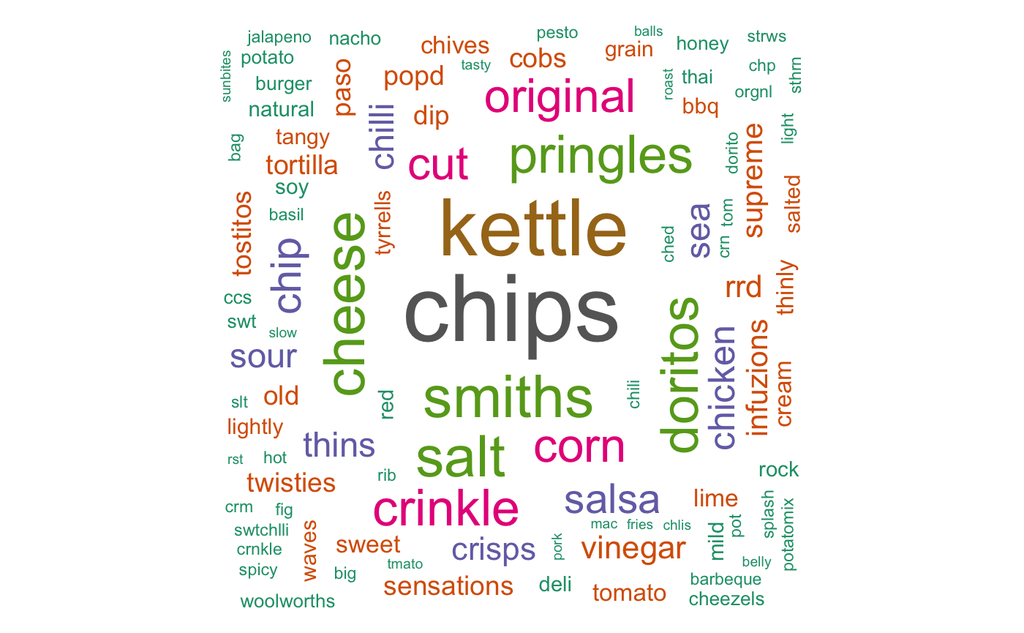

```r
set.seed(1234)
wordcloud(words = d$word, freq = d$freq, min.freq = 1,
          max.words=500, random.order=FALSE, rot.per=0.35,
          colors=brewer.pal(8, "Dark2"))
```

```r
#### sorting them by this frequency in order of highest to lowest frequency
#### Let's look at the most common words by counting the number of times a word appears and
# finding the most frequent term
frequency <- colSums(dtm2)
freq <- sort(frequency, decreasing = TRUE)
head(freq, n = 20L)
```

```
   chips   kettle   smiths     salt   cheese pringles  doritos  crinkle     corn original      cut     chip
   49770    41288    28860    27976    27890    25102    24962    23960    22063    21560    20754    18645
   salsa  chicken      sea    thins   chilli     sour   crisps  vinegar
   18094    15407    14145    14075    13895    13882    12607    12402
```

wordcloud

```r
# library(wordcloud)
words <- names(freq)

wordcloud(words[1:100], freq[1:100])
```

[output not shown]

There are salsa products in the dataset but we are only interested in the chips category, so let’s remove these.

```r
#### Remove salsa products
transactionData[, SALSA := grepl("salsa", tolower(PROD_NAME))]
transactionData <- transactionData[SALSA == FALSE, ][, SALSA := NULL]
head(transactionData)
```

```r
review_text <- paste(transactionData$PROD_NAME, collapse=" ")

review_source <- VectorSource(review_text)
corpus <- Corpus(review_source)

corpus <- tm_map(corpus, content_transformer(tolower))
corpus <- tm_map(corpus, removePunctuation)
corpus <- tm_map(corpus, stripWhitespace)
corpus <- tm_map(corpus, removeWords, stopwords(kind = "en"))

dtm <- DocumentTermMatrix(corpus)
dtm2 <- as.matrix(dtm)

frequency <- colSums(dtm2)
freq <- sort(frequency, decreasing = TRUE)
#head(freq, n = 20L)
```

```r
head(freq, n = 20L)
```

```r
#### Summarise the data to check for nulls and possible outliers
summary(transactionData)
```

```
      DATE              STORE_NBR     LYLTY_CARD_NBR        TXN_ID           PROD_NBR       PROD_NAME
 Min.   :2018-07-01   Min.   :  1.0   Min.   :   1000   Min.   :      1   Min.   :  1.00   Length:246742
 1st Qu.:2018-09-30   1st Qu.: 70.0   1st Qu.:  70015   1st Qu.:  67569   1st Qu.: 26.00   Class :character
 Median :2018-12-30   Median :130.0   Median : 130367   Median : 135183   Median : 53.00   Mode  :character
 Mean   :2018-12-30   Mean   :135.1   Mean   : 135531   Mean   : 135131   Mean   : 56.35
 3rd Qu.:2019-03-31   3rd Qu.:203.0   3rd Qu.: 203084   3rd Qu.: 202654   3rd Qu.: 87.00
 Max.   :2019-06-30   Max.   :272.0   Max.   :2373711   Max.   :2415841   Max.   :114.00
    PROD_QTY        TOT_SALES
 Min.   :  1.000   Length:246742
 1st Qu.:  2.000   Class :character
 Median :  2.000   Mode  :character
 Mean   :  1.908
 3rd Qu.:  2.000
 Max.   :200.000
```

There are no nulls in the columns but product quantity appears to have an outlier which we should investigate further. Let’s investigate further the case where 200 packets of chips are bought in one transaction.

```r
#### Filter the dataset to find the outlier
#library(ggplot2)

ggplot(transactionData) +
  aes(x ="", y = PROD_QTY) +
  geom_boxplot(fill = "#0c4c8a") +
  theme_minimal()
```

[output not shown]

```r
# library(dplyr)
outliers <- transactionData %>% filter(PROD_QTY >= 199)
outliers
```

[output not shown]

```r
#### Let's see if the customer has had other transactions
customer_transactions <- transactionData %>% filter(LYLTY_CARD_NBR == 226000)
customer_transactions
```

[output not shown]

```r
#### Filter out the customer based on the loyalty card number
# remove rows in r - subset function with multiple conditions
transactionData <- transactionData[!(transactionData$LYLTY_CARD_NBR==226000),]

#df2<-df1[!(df1$Name=="George" | df1$Name=="Andrea"),]

#df2

transactionData$LYLTY_CARD_NBR
```

```r
#### Re-examine transaction data
summary(transactionData)
```

```
      DATE              STORE_NBR     LYLTY_CARD_NBR        TXN_ID           PROD_NBR       PROD_NAME
 Min.   :2018-07-01   Min.   :  1.0   Min.   :   1000   Min.   :      1   Min.   :  1.00   Length:246740
 1st Qu.:2018-09-30   1st Qu.: 70.0   1st Qu.:  70015   1st Qu.:  67569   1st Qu.: 26.00   Class :character
 Median :2018-12-30   Median :130.0   Median : 130367   Median : 135182   Median : 53.00   Mode  :character
 Mean   :2018-12-30   Mean   :135.1   Mean   : 135530   Mean   : 135130   Mean   : 56.35
 3rd Qu.:2019-03-31   3rd Qu.:203.0   3rd Qu.: 203083   3rd Qu.: 202652   3rd Qu.: 87.00
 Max.   :2019-06-30   Max.   :272.0   Max.   :2373711   Max.   :2415841   Max.   :114.00
    PROD_QTY      TOT_SALES
 Min.   :1.000   Length:246740
 1st Qu.:2.000   Class :character
 Median :2.000   Mode  :character
 Mean   :1.906
 3rd Qu.:2.000
 Max.   :5.000
```

```r
#### Count the number of transactions by date

length(unique(transactionData[["DATE"]]))
```

```
[1] 364
```

There’s only 364 rows, meaning only 364 dates which indicates a missing date. Let’s create a sequence of dates from 1 Jul 2018 to 30 Jun 2019 and use this to create a chart of number of transactions over time to find the missing date.

```r
#### Create a sequence of dates and join this the count of transactions by date
# Over to you - create a column of dates that includes every day from 1 Jul 2018 to 30 Jun 2019, and join it onto the data to fill in the missing day.
# transactions_by_day <-
#         data.table(table(as.Date(transactionData$DATE)))
#         setnames(transactions_by_day, c('DATE', 'N'), skip_absent=TRUE)
transactions_by_day_2 <- transactionData[, .N, DATE][order(DATE)]
transactions_by_day_2
```

[output not shown]

[output cut: 354 more lines]

```r
# transactions_by_day$DATE <- as.Date(transactions_by_day$DATE, origin = "1899-12-30")
# print(transactions_by_day)
```

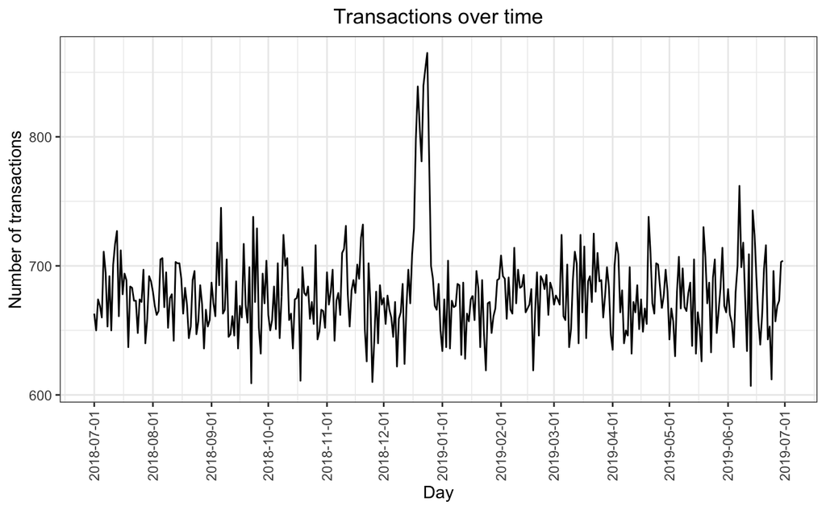

```r
#### Setting plot themes to format graphs
theme_set(theme_bw())
theme_update(plot.title = element_text(hjust = 0.5))
#### Plot transactions over time
ggplot(transactions_by_day, aes(x = DATE, y = N)) +
geom_line() +
labs(x = "Day", y = "Number of transactions", title = "Transactions over time") +
scale_x_date(breaks = "1 month") +
theme(axis.text.x = element_text(angle = 90, vjust = 0.5))
```

```r
#### Filter to December and look at individual days
december <- transactions_by_day %>% select(DATE, N) %>% filter(DATE >= as.Date("2018-12-01") & DATE <= as.Date("2018-12-31"))
december
```

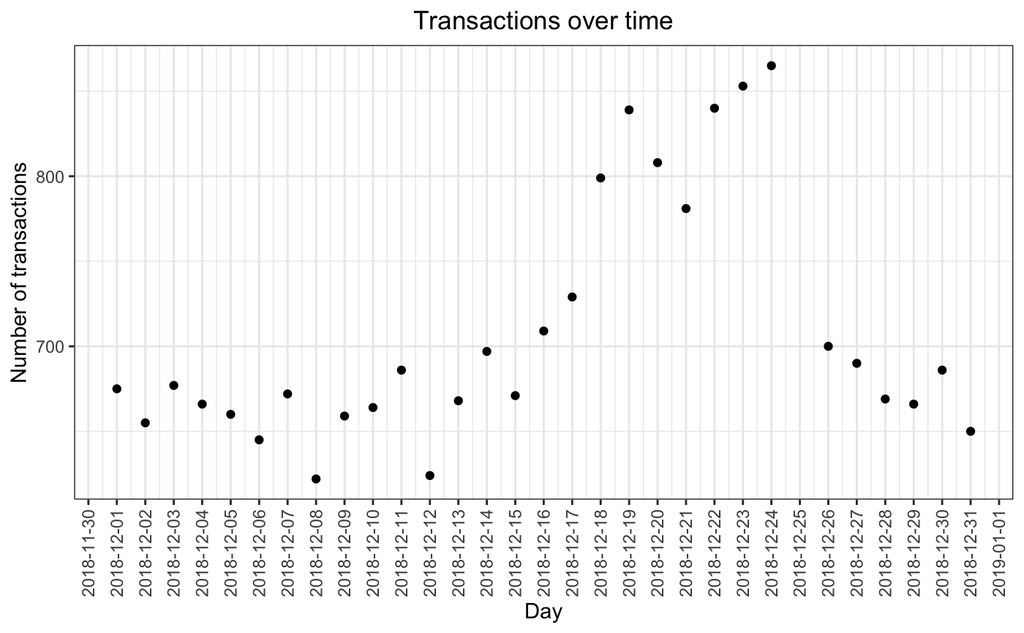

```r
#### Setting plot themes to format graphs
theme_set(theme_bw())
theme_update(plot.title = element_text(hjust = 0.5))
#### Plot transactions over time
ggplot(december, aes(x = DATE, y = N)) +
geom_point() +
labs(x = "Day", y = "Number of transactions", title = "Transactions over time") +
scale_x_date(breaks = "1 day") +
theme(axis.text.x = element_text(angle = 90, vjust = 0.5))
```

We can see that the increase in sales occurs in the lead-up to Christmas and that there are zero sales on Christmas day itself. This is due to shops being closed on Christmas day. Now that we are satisfied that the data no longer has outliers, we can move on to creating other features such as brand of chips or pack size from PROD_NAME. We will start with pack size.

```r
#### Pack size
#### We can work this out by taking the digits that are in PROD_NAME
filePath <- "/Volumes/Seagate_Haykay/Quantium_Data_Analytics"
transactionData2 <- fread(paste0(filePath,"/QVI_transaction_data.csv"))
transactionData2[, PACK_SIZE := parse_number(PROD_NAME)]



#### Always check your output
#### Let's check if the pack sizes look sensible
transactionData2[, .N, PACK_SIZE][order(N)]
```

| PACK_SIZE | N |
| --- | --- |
| 125 | 1454 |
| 180 | 1468 |
| 70 | 1507 |
| 220 | 1564 |
| 160 | 2970 |
| 190 | 2995 |
| 90 | 3008 |
| 250 | 3169 |
| 135 | 3257 |
| 200 | 4473 |

[output cut: 11 more lines]

The largest size is 380g and the smallest size is 70g - seems sensible!

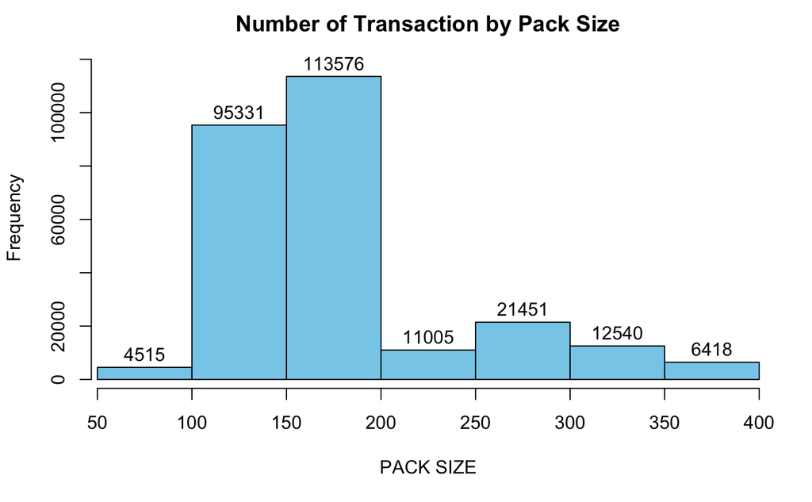

```r
#### Let's plot a histogram of PACK_SIZE since we know that it is a categorical variable and not a continuous variable even though it is numeric.
# Plot a histogram showing the number of transactions by pack size.

PACK_SIZE <- transactionData2$PACK_SIZE
h <- hist(PACK_SIZE,
main="Number of Transaction by Pack Size",
xlab="PACK SIZE",
xlim=c(60,390),
ylim=c(1400,120000),
breaks=10,
col="skyblue",
# freq=FALSE
)
text(h$mids,h$counts,labels=h$counts, adj=c(0.5, -0.5))
```

Now to create brands, we can use the first word in PROD_NAME to work out the brand name…

```r
#### Brands
# Over to you! Create a column which contains the brand of the product, by extracting it from the product name.
# library(stringr)
transactionData2$BRAND <- str_extract(transactionData2$PROD_NAME,"(\\w+)")
head(transactionData2, 20L)
```

[output not shown]

[output cut: 10 more lines]

```r
transactionData2[, .N, BRAND][order(BRAND)]
```

| BRAND | N |
| --- | --- |
| Burger | 1564 |
| CCs | 4551 |
| Cheetos | 2927 |
| Cheezels | 4603 |
| Cobs | 9693 |
| Dorito | 3185 |
| Doritos | 24962 |
| French | 1418 |
| Grain | 6272 |
| GrnWves | 1468 |

[output cut: 19 more lines]

Some of the brand names look like they are of the same brands - such as RED and RRD, which are both Red Rock Deli chips. Let’s combine these together.

```r
#### Clean brand names
transactionData2[BRAND == "Red", BRAND := "RRD"]
transactionData2[BRAND == "Infzns", BRAND := "Infuzions"]
transactionData2[BRAND == "Dorito", BRAND := "Doritos"]
transactionData2[BRAND == "Natural", BRAND := "NCC"]
transactionData2[BRAND == "Smith", BRAND := "Smiths"]
transactionData2[BRAND == "Snbts", BRAND := "Sunbites"]
transactionData2[BRAND == "Grain", BRAND := "GrnWves"]
transactionData2[BRAND == "WW", BRAND := "Woolworths"]
transactionData2[, .N, BRAND][order(BRAND)]
```

| BRAND | N |
| --- | --- |
| Burger | 1564 |
| CCs | 4551 |
| Cheetos | 2927 |
| Cheezels | 4603 |
| Cobs | 9693 |
| Doritos | 28147 |
| French | 1418 |
| GrnWves | 7740 |
| Infuzions | 14201 |
| Kettle | 41288 |

[output cut: 11 more lines]

```r
NA
```

### Examining customer data

Now that we are happy with the transaction dataset, let’s have a look at the customer dataset.

```r
summary(customerData)
```

```
 LYLTY_CARD_NBR     LIFESTAGE         PREMIUM_CUSTOMER
 Min.   :   1000   Length:72637       Length:72637
 1st Qu.:  66202   Class :character   Class :character
 Median : 134040   Mode  :character   Mode  :character
 Mean   : 136186
 3rd Qu.: 203375
 Max.   :2373711
```

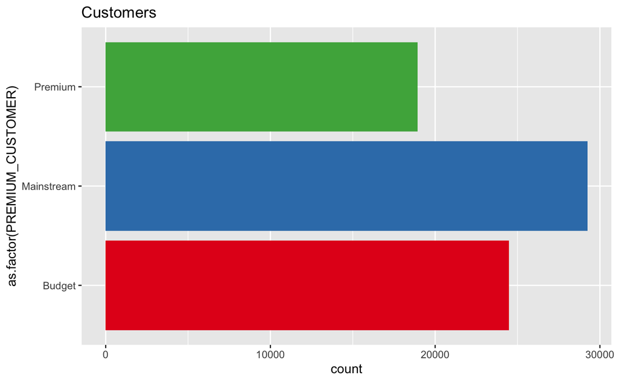

```r
# distributions of LYLTY_CARD_NBR key columns
# library(ggplot2)
# library(gganimate)
# library(tidyverse)

ggplot(customerData, aes(x=as.factor(PREMIUM_CUSTOMER), fill=as.factor(PREMIUM_CUSTOMER) )) +
  geom_bar( ) +
  scale_fill_brewer(palette = "Set1") +
  theme(legend.position="none") +
  coord_flip() +
  ggtitle("Customers")
```

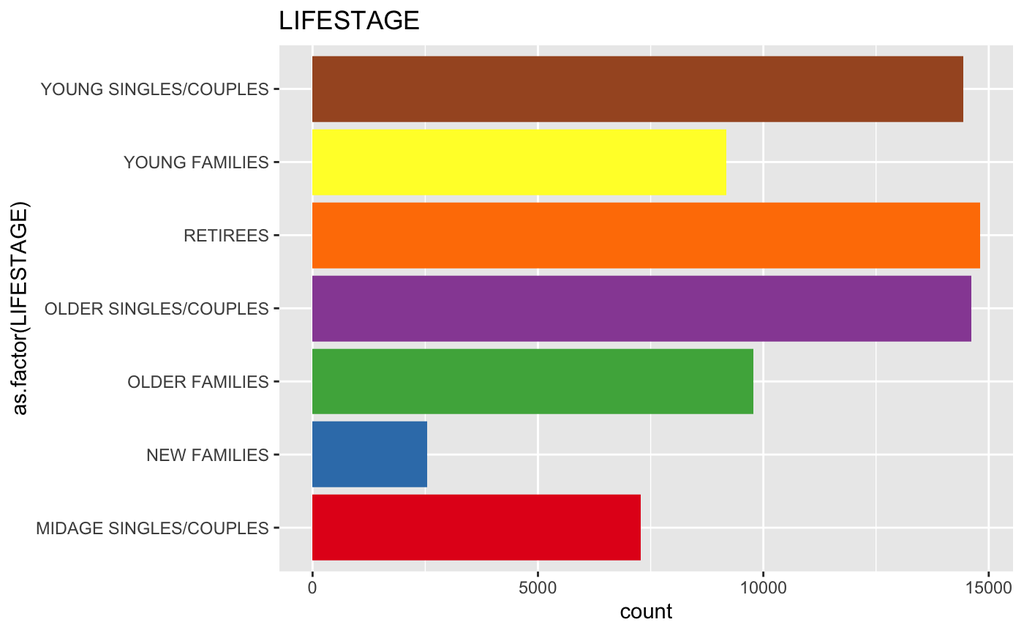

```r
ggplot(customerData, aes(x=as.factor(LIFESTAGE), fill=as.factor(LIFESTAGE) )) +
  geom_bar( ) +
  scale_fill_brewer(palette = "Set1") +
  theme(legend.position="none") +
  coord_flip() +
  ggtitle("LIFESTAGE")
```

```r
#### Merge transaction data to customer data
data <- merge(transactionData2, customerData, all.x = TRUE)
data
```

[output not shown]

[output cut: 990 more lines]

```r
total <- merge(transactionData2, customerData,by="LYLTY_CARD_NBR")
```

Let’s also check if some customers were not matched on by checking for nulls.

```r
# summary(data)

sum(is.na(data))
```

```
[1] 0
```

```r
# Find missing values in a column of a data frame

# which(is.na(expl_data1$x1))


# In order to get the positions of each column in your data set, you can use the apply() function

# apply(is.na(expl_data1), 2, which)
```

Note that if you are continuing with Task 2, you may want to retain this dataset which you can write out as a csv

```r
filePath <- "/Volumes/Seagate_Haykay/Quantium_Data_Analytics"
fwrite(data, paste0(filePath,"QVI_data.csv"))
write_csv(data,"/Volumes/Seagate_Haykay/Quantium_Data_Analytics/QVI_data.csv")
```